# Walthrough - Semi-Supervised and Association Rules

Jeff

March 11, 2026

## Semi-supervised - Weak/Granular labeling

Let’s start with a (hacky) use-case for semi-supervised learning, based on a real research question we have about mouse lung tissues.

Suppose your response-labelling process is at a different granular level than what your observations are.

Example: You are not allowed to ask a US citizen how they voted in the US election, but you do know their demographic information. In this case, you may have a sample of 800 people from California (went to Democrats), and 800 people from Texas (went to Republicans). It may be a reasonable assumption that your (representative) California sample has *more* democrats, and your (representative) Texas sample has *more* republicans. But it would not be reasonable to assume the state labels apply to the citizens, and fit in a fully supervised fashion.

We can simulate to show this of course. We will assume there are some consistent, measurable traits of democrats and republicans that are not region-specific.

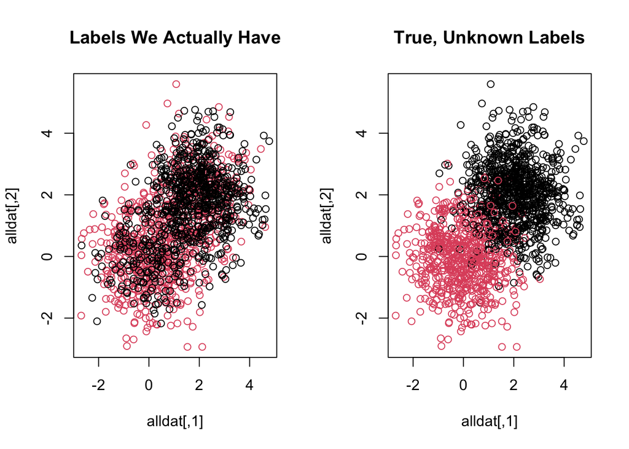

```r
set.seed(23511)
library(mvtnorm)
cali_r <- rmvnorm(300, mean=c(2,2))
cali_d <- rmvnorm(500, mean=c(0,0))
tex_r <- rmvnorm(620, mean=c(2,2))
tex_d <- rmvnorm(180, mean=c(0,0))
cali <- rbind(cali_r, cali_d)
tex <- rbind(tex_r, tex_d)
alldat <- rbind(cali, tex)
statelab <- rep(c(2,1), each=800)
unknowntrue <- rep(c(1,2,1,2), times=c(300,500,620,180))
par(mfrow=c(1,2))
plot(alldat, col=statelab, main="Labels We Actually Have")
plot(alldat, col=unknowntrue, main="True, Unknown Labels")
```

You can see, visually, where this is going. If we take a supervised approach on this granular label, our parameter estimation will be way off. Which means, if we’d actually like to use those to help describe the traits of the political parties, the supervised approach will be quite useless. Of course, our predictions for the model will suffer as well!

```r
#supervised discriminant analysis
library(teigen)
supmod <- teigen(alldat, Gs=2, known=statelab, scale=FALSE, models = "UUUU", verbose=FALSE)
trainpred <- predict(supmod, newdata=alldat)
table(unknowntrue, trainpred$classification)
```

```
##
## unknowntrue   1   2
##           1 853  67
##           2  55 625
```

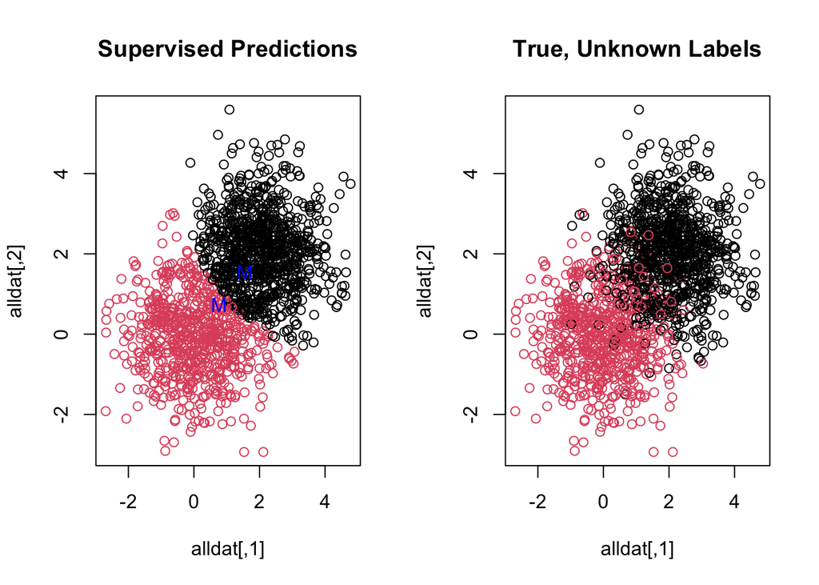

```r
par(mfrow=c(1,2))
plot(alldat, col=trainpred$classification, main="Supervised Predictions")
points(supmod$parameters$mean, col="blue", cex=1, pch="M")
plot(alldat, col=unknowntrue, main="True, Unknown Labels")
```

As expected, the group means are computed as nearly on top of one another. Our classification performance overall is okay, but there are some weird results from the plot. Also, since our normal densities are so similar for each group, our uncertainty in classification will be pretty high across the board. We can see this by just looking at a histogram for the probabilities associated with the groups:

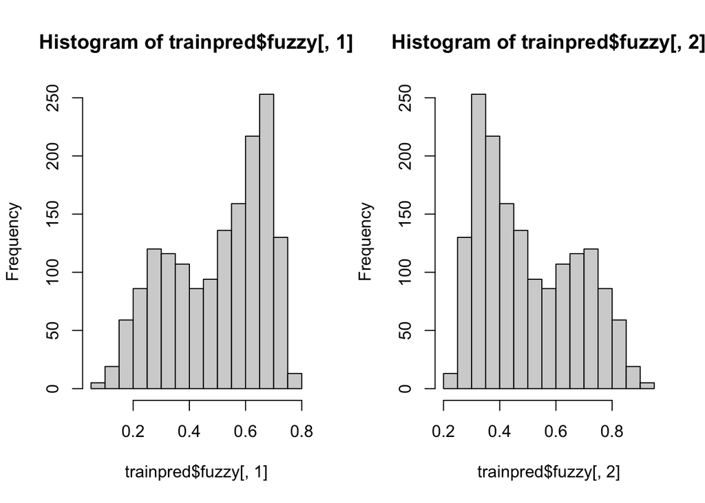

```r
par(mfrow=c(1,2))
hist(trainpred$fuzzy[,1])
hist(trainpred$fuzzy[,2])
```

Compare this to if we DID have the correct labelling…

```r
#supervised discriminant analysis, correct labels
library(teigen)
supmod2 <- teigen(alldat, Gs=2, known=unknowntrue, scale=FALSE, models = "UUUU", verbose=FALSE)
trainpred2 <- predict(supmod2, newdata=alldat)
table(unknowntrue, trainpred2$classification)
```

```
##
## unknowntrue   1   2
##           1 868  52
##           2  65 615
```

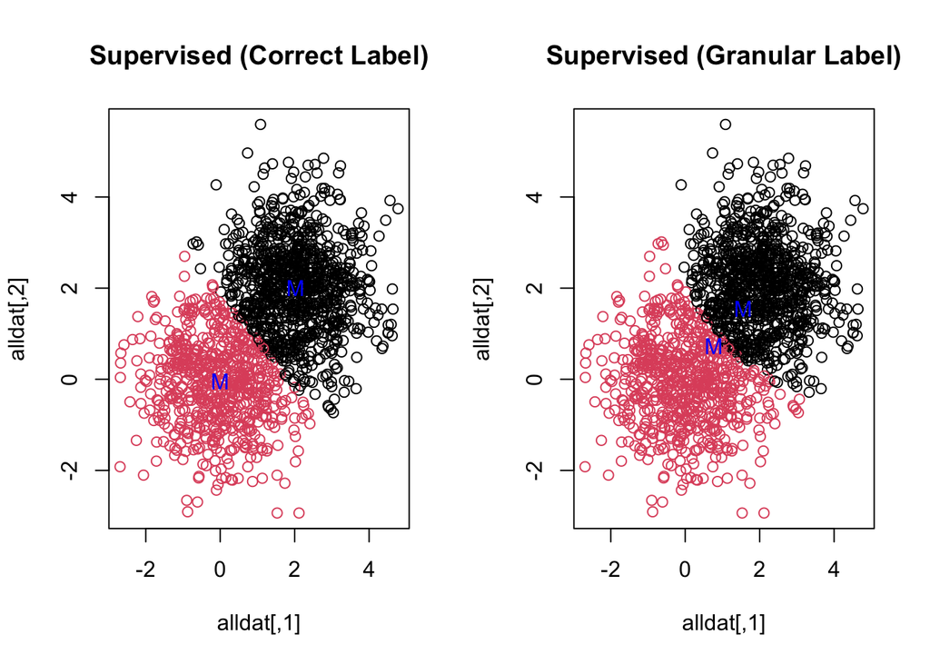

```r
par(mfrow=c(1,2))
plot(alldat, col=trainpred2$classification, main="Supervised (Correct Label)")
points(supmod2$parameters$mean, col="blue", cex=1, pch="M")
plot(alldat, col=trainpred$classification, main="Supervised (Granular Label)")
points(supmod$parameters$mean, col="blue", cex=1, pch="M")
```

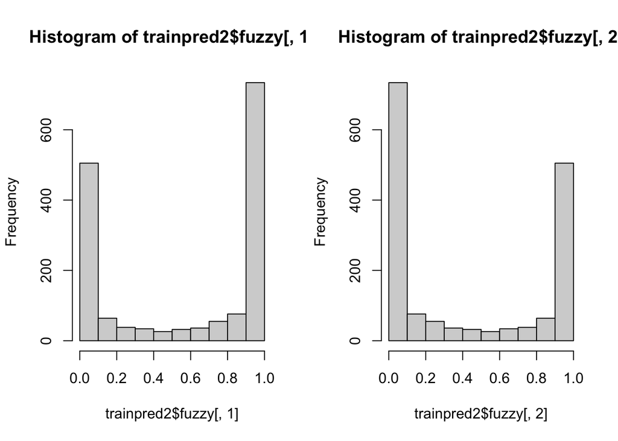

```r
par(mfrow=c(1,2))
hist(trainpred2$fuzzy[,1])
hist(trainpred2$fuzzy[,2])
```

So now we’ve seen the granular case, and the (impossible by the setup of our problem) best case scenario. Can we approximate the best case scenario using semi-supervised instead?

The basic idea is that we can label some subset of the observations using the granular label, and let the mixture model sort out the rest. The less we label, the closer we get to unsupervised (which would actually work okay in this scenario probably).

For no particular reason, let’s randomly sample 10% as firm labels.

```r
#semi-supervised
library(teigen)
set.seed(35131)
substatelab <- rep(NA, nrow(alldat))
sampind <- sample(1:nrow(alldat), .1*nrow(alldat))
substatelab[sampind] <- statelab[sampind]
semimod <- teigen(alldat, Gs=2, init="uniform", known=substatelab, scale=FALSE, models = "UUUU", verbose=FALSE)
trainpred3 <- predict(semimod, newdata=alldat)
table(unknowntrue, semimod$classification)
```

```
##
## unknowntrue   1   2
##           1 809 111
##           2  62 618
```

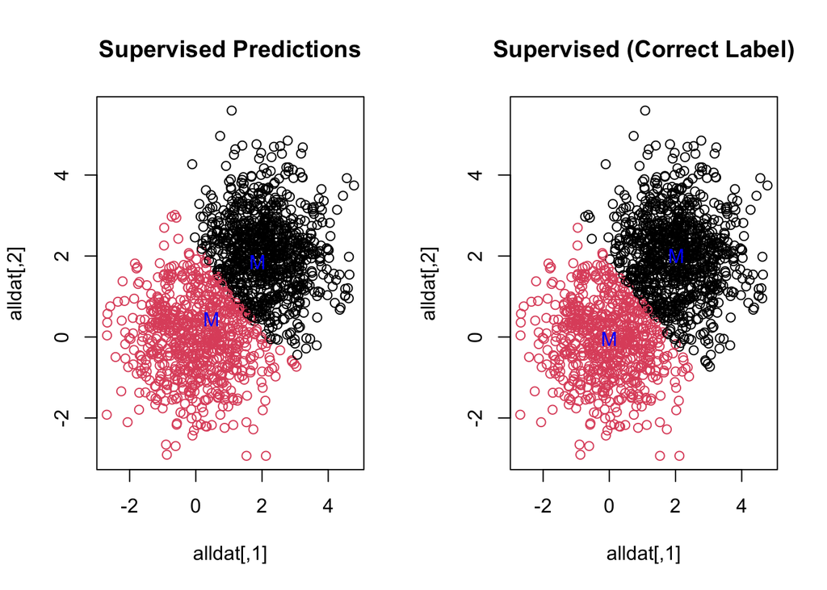

```r
par(mfrow=c(1,2))
plot(alldat, col=trainpred3$classification, main="Supervised Predictions")
points(semimod$parameters$mean, col="blue", cex=1, pch="M")
plot(alldat, col=trainpred2$classification, main="Supervised (Correct Label)")
points(supmod2$parameters$mean, col="blue", cex=1, pch="M")
```

Similar to the fully supervised on granular labels, we’re taking some observations as ‘known’ to be in the *wrong* group. Our misclassification rate has gone up, but the mean estimates are heading in the right direction. If, however, we have a reasonable guess of a few observations that we’re confident in labeling (think back to the bias labeling example from lecture), we can fix this problem! In fact, we can fix it with a very minimal number of correct labels.

Let’s suppose we were confident of one extreme citizen in each direction. That is, if someone measures high on both variables they are almost certainly a republican and if someone measures low on both then they are almost certainly a democrat…

```r
#semi-supervised
library(teigen)
substatelab2 <- rep(NA, nrow(alldat))
extremeDem <- which.min(rowSums(alldat))
extremeRep <- which.max(rowSums(alldat))
substatelab2[extremeDem] <- 2
substatelab2[extremeRep] <- 1
semimod2 <- teigen(alldat, Gs=2, init="uniform", known=substatelab2, scale=FALSE, models = "UUUU", verbose=FALSE)
trainpred4 <- predict(semimod2, newdata=alldat)
table(unknowntrue, semimod2$classification)
```

```
##
## unknowntrue   1   2
##           1 869  51
##           2  66 614
```

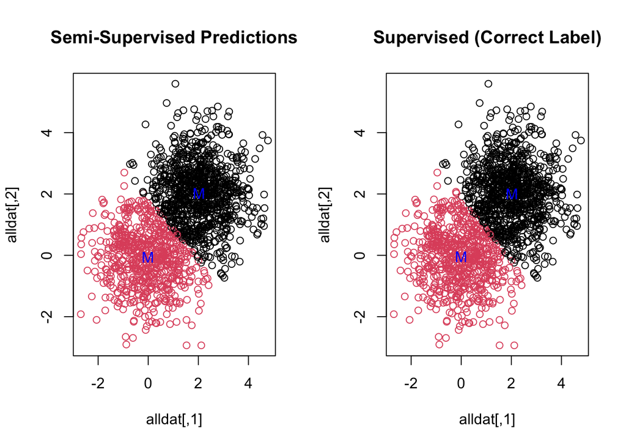

```r
par(mfrow=c(1,2))
plot(alldat, col=trainpred4$classification, main="Semi-Supervised Predictions")
points(semimod2$parameters$mean, col="blue", cex=1, pch="M")
plot(alldat, col=trainpred2$classification, main="Supervised (Correct Label)")
points(supmod2$parameters$mean, col="blue", cex=1, pch="M")
```

In case you’re interested in how this conceptually works with our mouse lung research question…we can label regions of the lung fairly easily as containing (or not) fibrotic tissue. Our observations, though, are measurements on individual cells within these regions. Even in fibrotic areas, cells will be a mix of both fibrotic and normal. Luckily, we are fairly confident that the normal tissue areas will not contain fibrotic cells — which actually makes the problem easier than our voting example! The equivalent in that case: being able to assume the California label applies to all its citizens, and only needing to relax the Texas label in a semi-supervised fashion.

## Association Rules

We saw association rules in the context of actual transactions, but they can also be viewed on categorical data by using what’s commonly called one-hot encoding. All it means is making an indicator variable for each level of the factor. The `arules` package can coerce factors into the desired form using the `as()` function. Let’s check out some survey data…

```r
#install.packages("arules")
#install.packages("effects")
library(arules)
library(effects)
data(WVS)
head(WVS)
```

```
##       poverty religion degree country age gender
## 1  Too Little      yes     no     USA  44   male
## 2 About Right      yes     no     USA  40 female
## 3  Too Little      yes     no     USA  36 female
## 4    Too Much      yes    yes     USA  25 female
## 5  Too Little      yes    yes     USA  39   male
## 6 About Right      yes     no     USA  80 female
```

Note that there is one numeric variable in here. Let’s investigate how broadly it varies

```r
summary(WVS$age)
```

```
##    Min. 1st Qu.  Median    Mean 3rd Qu.    Max.
##   18.00   31.00   43.00   45.04   58.00   92.00
```

Let’s discretize that measure to make it categorical according to four equally spaced intervals.

```r
WVS$age <- discretize(WVS$age, method="interval", breaks=4)
table(WVS$age)
```

```
##
## [18,36.5) [36.5,55) [55,73.5) [73.5,92]
##      1985      1825      1208       363
```

Now we can feed this into the apriori algorithm

```r
asurv <- apriori(WVS)
```

```
## Apriori
##
## Parameter specification:
##  confidence minval smax arem  aval originalSupport maxtime support minlen
##         0.8    0.1    1 none FALSE            TRUE       5     0.1      1
##  maxlen target  ext
##      10  rules TRUE
##
## Algorithmic control:
##  filter tree heap memopt load sort verbose
##     0.1 TRUE TRUE  FALSE TRUE    2    TRUE
##
## Absolute minimum support count: 538
##
## set item appearances ...[0 item(s)] done [0.00s].
## set transactions ...[17 item(s), 5381 transaction(s)] done [0.00s].
## sorting and recoding items ... [16 item(s)] done [0.00s].
## creating transaction tree ... done [0.00s].
## checking subsets of size 1 2 3 4 done [0.00s].
## writing ... [68 rule(s)] done [0.00s].
## creating S4 object  ... done [0.00s].
```

```r
summary(asurv)
```

```
## set of 68 rules
##
## rule length distribution (lhs + rhs):sizes
##  1  2  3  4
##  1 15 37 15
##
##    Min. 1st Qu.  Median    Mean 3rd Qu.    Max.
##   1.000   3.000   3.000   2.971   3.000   4.000
##
## summary of quality measures:
##     support         confidence        coverage           lift
##  Min.   :0.1015   Min.   :0.8004   Min.   :0.1109   Min.   :0.9373
##  1st Qu.:0.1229   1st Qu.:0.8325   1st Qu.:0.1410   1st Qu.:0.9856
##  Median :0.1577   Median :0.8535   Median :0.1801   Median :1.0153
##  Mean   :0.1989   Mean   :0.8669   Mean   :0.2308   Mean   :1.0371
##  3rd Qu.:0.2196   3rd Qu.:0.8978   3rd Qu.:0.2589   3rd Qu.:1.0715
##  Max.   :0.8539   Max.   :0.9884   Max.   :1.0000   Max.   :1.1919
##      count
##  Min.   : 546.0
##  1st Qu.: 661.2
##  Median : 848.5
##  Mean   :1070.4
##  3rd Qu.:1181.5
##  Max.   :4595.0
##
## mining info:
##  data ntransactions support confidence                call
##   WVS          5381     0.1        0.8 apriori(data = WVS)
```

```r
inspect(sort(asurv, by="support")[1:10])
```

```
##      lhs                                rhs            support   confidence
## [1]  {}                              => {religion=yes} 0.8539305 0.8539305
## [2]  {degree=no}                     => {religion=yes} 0.6710649 0.8520529
## [3]  {gender=female}                 => {religion=yes} 0.4471288 0.8829358
## [4]  {poverty=Too Little}            => {religion=yes} 0.4302174 0.8548744
## [5]  {gender=male}                   => {religion=yes} 0.4068017 0.8241717
## [6]  {degree=no, gender=female}      => {religion=yes} 0.3477049 0.8804706
## [7]  {poverty=Too Little, degree=no} => {religion=yes} 0.3438023 0.8584687
## [8]  {degree=no, gender=male}        => {religion=yes} 0.3233600 0.8234737
## [9]  {country=Australia}             => {degree=no}    0.3213157 0.9226254
## [10] {age=[18,36.5)}                 => {religion=yes} 0.3051477 0.8272040
##      coverage  lift      count
## [1]  1.0000000 1.0000000 4595
## [2]  0.7875860 0.9978012 3611
## [3]  0.5064114 1.0339668 2406
## [4]  0.5032522 1.0011054 2315
## [5]  0.4935886 0.9651508 2189
## [6]  0.3949080 1.0310799 1871
## [7]  0.4004832 1.0053145 1850
## [8]  0.3926779 0.9643334 1740
## [9]  0.3482624 1.1714600 1729
## [10] 0.3688905 0.9687018 1642
```

```r
inspect(sort(asurv, by="confidence")[1:10])
```

```
##      lhs                      rhs              support confidence  coverage     lift count
## [1]  {poverty=Too Little,
##       country=Sweden}      => {religion=yes} 0.1109459  0.9884106 0.1122468 1.157484   597
## [2]  {country=Sweden}      => {religion=yes} 0.1836090  0.9850449 0.1863966 1.153542   988
## [3]  {degree=no,
##       country=Sweden}      => {religion=yes} 0.1289723  0.9816124 0.1313882 1.149523   694
## [4]  {religion=yes,
##       country=Australia,
##       gender=female}       => {degree=no}    0.1423527  0.9387255 0.1516447 1.191902   766
## [5]  {religion=yes,
##       country=Australia}   => {degree=no}    0.2601747  0.9339560 0.2785728 1.185846  1400
## [6]  {poverty=Too Little,
##       religion=yes,
##       country=Australia}   => {degree=no}    0.1315741  0.9291339 0.1416094 1.179724   708
## [7]  {religion=yes,
##       country=Australia,
##       gender=male}         => {degree=no}    0.1178220  0.9282577 0.1269281 1.178611   634
## [8]  {country=Australia,
##       gender=female}       => {degree=no}    0.1668835  0.9267286 0.1800781 1.176670   898
## [9]  {age=[55,73.5),
##       gender=female}       => {religion=yes} 0.1042557  0.9226974 0.1129902 1.080530   561
## [10] {country=Australia}   => {degree=no}    0.3213157  0.9226254 0.3482624 1.171460  1729
```

```r
inspect(sort(asurv, by="lift")[1:10])
```

```
##      lhs                      rhs              support confidence  coverage     lift count
## [1]  {religion=yes,
##       country=Australia,
##       gender=female}       => {degree=no}    0.1423527  0.9387255 0.1516447 1.191902   766
## [2]  {religion=yes,
##       country=Australia}   => {degree=no}    0.2601747  0.9339560 0.2785728 1.185846  1400
## [3]  {poverty=Too Little,
##       religion=yes,
##       country=Australia}   => {degree=no}    0.1315741  0.9291339 0.1416094 1.179724   708
## [4]  {religion=yes,
##       country=Australia,
##       gender=male}         => {degree=no}    0.1178220  0.9282577 0.1269281 1.178611   634
## [5]  {country=Australia,
##       gender=female}       => {degree=no}    0.1668835  0.9267286 0.1800781 1.176670   898
## [6]  {country=Australia}   => {degree=no}    0.3213157  0.9226254 0.3482624 1.171460  1729
## [7]  {country=Australia,
##       gender=male}         => {degree=no}    0.1544323  0.9182320 0.1681844 1.165882   831
## [8]  {poverty=Too Little,
##       country=Australia}   => {degree=no}    0.1624233  0.9180672 0.1769188 1.165672   874
## [9]  {country=Australia,
##       age=[36.5,55)}       => {degree=no}    0.1014681  0.9145729 0.1109459 1.161236   546
## [10] {poverty=Too Little,
##       country=Sweden}      => {religion=yes} 0.1109459  0.9884106 0.1122468 1.157484   597
```

```r
inspect(sort(asurv, by="lift", decreasing=FALSE)[1:10])
```

```
##      lhs                       rhs              support confidence  coverage      lift count
## [1]  {poverty=Too Little,
##       country=Australia}    => {religion=yes} 0.1416094  0.8004202 0.1769188 0.9373364   762
## [2]  {poverty=About Right,
##       age=[18,36.5)}        => {religion=yes} 0.1022115  0.8076358 0.1265564 0.9457864   550
## [3]  {degree=no,
##       country=Australia}    => {religion=yes} 0.2601747  0.8097166 0.3213157 0.9482231  1400
## [4]  {poverty=Too Little,
##       degree=no,
##       country=Australia}    => {religion=yes} 0.1315741  0.8100686 0.1624233 0.9486353   708
## [5]  {degree=no,
##       age=[18,36.5)}        => {religion=yes} 0.2295112  0.8141068 0.2819179 0.9533642  1235
## [6]  {poverty=About Right,
##       degree=no,
##       gender=male}          => {religion=yes} 0.1137335  0.8181818 0.1390076 0.9581363   612
## [7]  {degree=no,
##       age=[36.5,55),
##       gender=male}          => {religion=yes} 0.1089017  0.8207283 0.1326891 0.9611184   586
## [8]  {poverty=About Right,
##       gender=male}          => {religion=yes} 0.1481137  0.8216495 0.1802639 0.9621971   797
## [9]  {degree=no,
##       gender=male}          => {religion=yes} 0.3233600  0.8234737 0.3926779 0.9643334  1740
## [10] {age=[36.5,55),
##       gender=male}          => {religion=yes} 0.1417952  0.8239741 0.1720870 0.9649194   763
```

And we can adjust thresholds…

```r
asurv <- apriori(WVS, parameter=list(supp=0.04, conf=.8))
```

```
## Apriori
##
## Parameter specification:
##  confidence minval smax arem  aval originalSupport maxtime support minlen
##         0.8    0.1    1 none FALSE            TRUE       5    0.04      1
##  maxlen target  ext
##      10  rules TRUE
##
## Algorithmic control:
##  filter tree heap memopt load sort verbose
##     0.1 TRUE TRUE  FALSE TRUE    2    TRUE
##
## Absolute minimum support count: 215
##
## set item appearances ...[0 item(s)] done [0.00s].
## set transactions ...[17 item(s), 5381 transaction(s)] done [0.00s].
## sorting and recoding items ... [17 item(s)] done [0.00s].
## creating transaction tree ... done [0.00s].
## checking subsets of size 1 2 3 4 5 done [0.00s].
## writing ... [200 rule(s)] done [0.00s].
## creating S4 object  ... done [0.00s].
```

```r
summary(asurv)
```

```
## set of 200 rules
##
## rule length distribution (lhs + rhs):sizes
##  1  2  3  4  5
##  1 17 80 85 17
##
##    Min. 1st Qu.  Median    Mean 3rd Qu.    Max.
##     1.0     3.0     4.0     3.5     4.0     5.0
##
## summary of quality measures:
##     support          confidence        coverage            lift
##  Min.   :0.04051   Min.   :0.8000   Min.   :0.04144   Min.   :0.9368
##  1st Qu.:0.05482   1st Qu.:0.8420   1st Qu.:0.06142   1st Qu.:0.9965
##  Median :0.07406   Median :0.8801   Median :0.08614   Median :1.0444
##  Mean   :0.10924   Mean   :0.8833   Mean   :0.12534   Mean   :1.0602
##  3rd Qu.:0.12433   3rd Qu.:0.9176   3rd Qu.:0.14245   3rd Qu.:1.1403
##  Max.   :0.85393   Max.   :0.9967   Max.   :1.00000   Max.   :1.2331
##      count
##  Min.   : 218.0
##  1st Qu.: 295.0
##  Median : 398.5
##  Mean   : 587.8
##  3rd Qu.: 669.0
##  Max.   :4595.0
##
## mining info:
##  data ntransactions support confidence
##   WVS          5381    0.04        0.8
##                                                            call
##  apriori(data = WVS, parameter = list(supp = 0.04, conf = 0.8))
```

```r
inspect(sort(asurv, by="support")[1:10])
```

```
##      lhs                                rhs            support   confidence
## [1]  {}                              => {religion=yes} 0.8539305 0.8539305
## [2]  {degree=no}                     => {religion=yes} 0.6710649 0.8520529
## [3]  {gender=female}                 => {religion=yes} 0.4471288 0.8829358
## [4]  {poverty=Too Little}            => {religion=yes} 0.4302174 0.8548744
## [5]  {gender=male}                   => {religion=yes} 0.4068017 0.8241717
## [6]  {degree=no, gender=female}      => {religion=yes} 0.3477049 0.8804706
## [7]  {poverty=Too Little, degree=no} => {religion=yes} 0.3438023 0.8584687
## [8]  {degree=no, gender=male}        => {religion=yes} 0.3233600 0.8234737
## [9]  {country=Australia}             => {degree=no}    0.3213157 0.9226254
## [10] {age=[18,36.5)}                 => {religion=yes} 0.3051477 0.8272040
##      coverage  lift      count
## [1]  1.0000000 1.0000000 4595
## [2]  0.7875860 0.9978012 3611
## [3]  0.5064114 1.0339668 2406
## [4]  0.5032522 1.0011054 2315
## [5]  0.4935886 0.9651508 2189
## [6]  0.3949080 1.0310799 1871
## [7]  0.4004832 1.0053145 1850
## [8]  0.3926779 0.9643334 1740
## [9]  0.3482624 1.1714600 1729
## [10] 0.3688905 0.9687018 1642
```

```r
inspect(sort(asurv, by="confidence")[1:10])
```

```
##      lhs                       rhs               support confidence   coverage     lift count
## [1]  {poverty=Too Little,
##       country=Sweden,
##       gender=male}          => {religion=yes} 0.05538004  0.9966555 0.05556588 1.167139   298
## [2]  {poverty=Too Little,
##       degree=no,
##       country=Sweden,
##       gender=male}          => {religion=yes} 0.04292882  0.9956897 0.04311466 1.166008   231
## [3]  {degree=yes,
##       country=Sweden}       => {religion=yes} 0.05463668  0.9932432 0.05500836 1.163143   294
## [4]  {poverty=Too Little,
##       country=Sweden,
##       age=[18,36.5)}        => {religion=yes} 0.04107043  0.9910314 0.04144211 1.160553   221
## [5]  {poverty=Too Little,
##       country=Sweden}       => {religion=yes} 0.11094592  0.9884106 0.11224679 1.157484   597
## [6]  {country=Sweden,
##       gender=male}          => {religion=yes} 0.09366289  0.9882353 0.09477792 1.157278   504
## [7]  {poverty=Too Little,
##       country=Sweden,
##       age=[36.5,55)}        => {religion=yes} 0.04292882  0.9871795 0.04348634 1.156042   231
## [8]  {poverty=Too Little,
##       degree=no,
##       country=Sweden}       => {religion=yes} 0.08288422  0.9867257 0.08399926 1.155511   446
## [9]  {degree=no,
##       country=Sweden,
##       gender=male}          => {religion=yes} 0.06876045  0.9866667 0.06968965 1.155441   370
## [10] {poverty=About Right,
##       country=Sweden}       => {religion=yes} 0.06857461  0.9866310 0.06950381 1.155400   369
```

```r
inspect(sort(asurv, by="lift")[1:10])
```

```
##      lhs                       rhs            support confidence   coverage     lift count
## [1]  {religion=yes,
##       country=Australia,
##       age=[55,73.5)}        => {degree=no} 0.06262776  0.9711816 0.06448615 1.233112   337
## [2]  {poverty=Too Much,
##       religion=yes,
##       country=Australia}    => {degree=no} 0.04627393  0.9688716 0.04776064 1.230179   249
## [3]  {country=Australia,
##       age=[55,73.5)}        => {degree=no} 0.07061884  0.9644670 0.07322059 1.224586   380
## [4]  {poverty=Too Much,
##       country=Australia}    => {degree=no} 0.05352165  0.9600000 0.05575172 1.218915   288
## [5]  {religion=yes,
##       country=Australia,
##       age=[36.5,55),
##       gender=female}        => {degree=no} 0.04515889  0.9529412 0.04738896 1.209952   243
## [6]  {poverty=About Right,
##       religion=yes,
##       country=Australia,
##       gender=female}        => {degree=no} 0.04330050  0.9433198 0.04590225 1.197736   233
## [7]  {poverty=Too Little,
##       religion=yes,
##       country=Australia,
##       gender=male}          => {degree=no} 0.05835347  0.9401198 0.06207025 1.193673   314
## [8]  {religion=yes,
##       country=Australia,
##       gender=female}        => {degree=no} 0.14235272  0.9387255 0.15164468 1.191902   766
## [9]  {religion=yes,
##       country=Australia,
##       age=[36.5,55)}        => {degree=no} 0.08083999  0.9375000 0.08622933 1.190346   435
## [10] {religion=yes,
##       country=Australia}    => {degree=no} 0.26017469  0.9339560 0.27857276 1.185846  1400
```

```r
inspect(sort(asurv, by="lift", decreasing=FALSE)[1:10])
```

```
##      lhs                       rhs               support confidence   coverage      lift count
## [1]  {country=Australia,
##       age=[18,36.5),
##       gender=female}        => {religion=yes} 0.06021186  0.8000000 0.07526482 0.9368444   324
## [2]  {poverty=Too Little,
##       country=Australia}    => {religion=yes} 0.14160937  0.8004202 0.17691879 0.9373364   762
## [3]  {poverty=Too Much,
##       degree=no,
##       gender=male}          => {religion=yes} 0.04868983  0.8036810 0.06058353 0.9411550   262
## [4]  {poverty=About Right,
##       age=[18,36.5)}        => {religion=yes} 0.10221148  0.8076358 0.12655640 0.9457864   550
## [5]  {poverty=Too Much,
##       gender=male}          => {religion=yes} 0.06207025  0.8087167 0.07675153 0.9470521   334
## [6]  {degree=no,
##       country=Australia,
##       age=[18,36.5),
##       gender=female}        => {religion=yes} 0.05445085  0.8093923 0.06727374 0.9478433   293
## [7]  {degree=no,
##       country=Australia}    => {religion=yes} 0.26017469  0.8097166 0.32131574 0.9482231  1400
## [8]  {poverty=Too Little,
##       degree=no,
##       country=Australia}    => {religion=yes} 0.13157406  0.8100686 0.16242334 0.9486353   708
## [9]  {poverty=About Right,
##       country=USA}          => {religion=yes} 0.05612340  0.8118280 0.06913213 0.9506956   302
## [10] {poverty=Too Little,
##       degree=no,
##       age=[18,36.5),
##       gender=male}          => {religion=yes} 0.05853930  0.8118557 0.07210556 0.9507280   315
```

## Code for Lecture (Grocery Example)

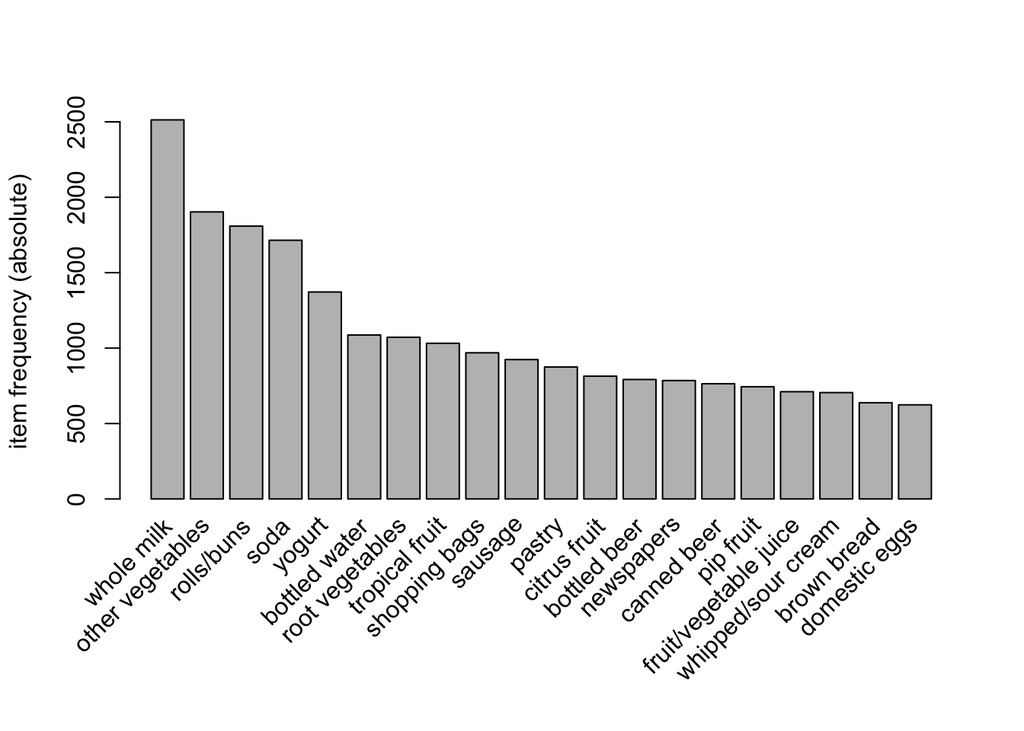

```r
library(arules)
data("Groceries")
itemFrequencyPlot(Groceries, topN=20, type="absolute")
```

```r
arun <- apriori(Groceries, parameter=list(supp = 0.001, conf = 0.8))
```

```
## Apriori
##
## Parameter specification:
##  confidence minval smax arem  aval originalSupport maxtime support minlen
##         0.8    0.1    1 none FALSE            TRUE       5   0.001      1
##  maxlen target  ext
##      10  rules TRUE
##
## Algorithmic control:
##  filter tree heap memopt load sort verbose
##     0.1 TRUE TRUE  FALSE TRUE    2    TRUE
##
## Absolute minimum support count: 9
##
## set item appearances ...[0 item(s)] done [0.00s].
## set transactions ...[169 item(s), 9835 transaction(s)] done [0.00s].
## sorting and recoding items ... [157 item(s)] done [0.00s].
## creating transaction tree ... done [0.00s].
## checking subsets of size 1 2 3 4 5 6 done [0.01s].
## writing ... [410 rule(s)] done [0.00s].
## creating S4 object  ... done [0.00s].
```

```r
inspect(arun[1:5])
```

```
##     lhs                         rhs            support     confidence
## [1] {liquor, red/blush wine} => {bottled beer} 0.001931876 0.9047619
## [2] {curd, cereals}          => {whole milk}   0.001016777 0.9090909
## [3] {yogurt, cereals}        => {whole milk}   0.001728521 0.8095238
## [4] {butter, jam}            => {whole milk}   0.001016777 0.8333333
## [5] {soups, bottled beer}    => {whole milk}   0.001118454 0.9166667
##     coverage    lift      count
## [1] 0.002135231 11.235269 19
## [2] 0.001118454  3.557863 10
## [3] 0.002135231  3.168192 17
## [4] 0.001220132  3.261374 10
## [5] 0.001220132  3.587512 11
```

```r
inspect(sort(arun, by="support")[1:5])
```

```
##     lhs                    rhs                    support confidence    coverage     lift count
## [1] {citrus fruit,
##      tropical fruit,
##      root vegetables,
##      whole milk}        => {other vegetables} 0.003152008  0.8857143 0.003558719 4.577509    31
## [2] {other vegetables,
##      curd,
##      domestic eggs}     => {whole milk}       0.002846975  0.8235294 0.003457041 3.223005    28
## [3] {hamburger meat,
##      curd}              => {whole milk}       0.002541942  0.8064516 0.003152008 3.156169    25
## [4] {herbs,
##      rolls/buns}        => {whole milk}       0.002440264  0.8000000 0.003050330 3.130919    24
## [5] {tropical fruit,
##      herbs}             => {whole milk}       0.002338587  0.8214286 0.002846975 3.214783    23
```

```r
inspect(sort(arun, by="confidence")[1:5])
```

```
##     lhs                      rhs              support confidence    coverage     lift count
## [1] {rice,
##      sugar}               => {whole milk} 0.001220132          1 0.001220132 3.913649    12
## [2] {canned fish,
##      hygiene articles}    => {whole milk} 0.001118454          1 0.001118454 3.913649    11
## [3] {root vegetables,
##      butter,
##      rice}                => {whole milk} 0.001016777          1 0.001016777 3.913649    10
## [4] {root vegetables,
##      whipped/sour cream,
##      flour}               => {whole milk} 0.001728521          1 0.001728521 3.913649    17
## [5] {butter,
##      soft cheese,
##      domestic eggs}       => {whole milk} 0.001016777          1 0.001016777 3.913649    10
```

```r
inspect(sort(arun, by="lift")[1:5])
```

```
##     lhs                        rhs                   support confidence    coverage      lift count
## [1] {liquor,
##      red/blush wine}        => {bottled beer}    0.001931876  0.9047619 0.002135231 11.235269    19
## [2] {citrus fruit,
##      other vegetables,
##      soda,
##      fruit/vegetable juice} => {root vegetables} 0.001016777  0.9090909 0.001118454  8.340400    10
## [3] {tropical fruit,
##      other vegetables,
##      whole milk,
##      yogurt,
##      oil}                   => {root vegetables} 0.001016777  0.9090909 0.001118454  8.340400    10
## [4] {citrus fruit,
##      grapes,
##      fruit/vegetable juice} => {tropical fruit}  0.001118454  0.8461538 0.001321810  8.063879    11
## [5] {other vegetables,
##      whole milk,
##      yogurt,
##      rice}                  => {root vegetables} 0.001321810  0.8666667 0.001525165  7.951182    13
```